# Spruce wood time series VST blind vs. aware comparison

Nicolas Delhomme

2016-10-20

# 1 Setup

```r
suppressPackageStartupMessages(library(DESeq2))
suppressPackageStartupMessages(library(gplots))
suppressPackageStartupMessages(library(pander))
suppressPackageStartupMessages(library(parallel))
suppressPackageStartupMessages(library(RColorBrewer))
suppressPackageStartupMessages(library(scatterplot3d))
suppressPackageStartupMessages(library(VennDiagram))
suppressPackageStartupMessages(library(vsn))
```

helpers

```r
source("~/Git/UPSCb/src/R/plot.multidensity.R")
```

graphic params

```r
mar <- par("mar")
cols <- brewer.pal(8,"Dark2")
```

The working dir

```r
setwd("/mnt/picea/projects/spruce/htuominen/27_SpruceTimeSeries")
```

Read the sample information

```r
samples <- read.csv("~/Git/UPSCb/projects/spruce-wood-time-series/doc/samplesmod.csv")
```

# 2 Process

Read the HTSeq files in a matrix

```r
res <- mclapply(dir("htseq",pattern="*STAR.txt",full.names=TRUE),function(fil){
  read.delim(fil,header=FALSE,stringsAsFactors=FALSE)
},mc.cores=max(mcaffinity()))
names(res) <- gsub("_STAR\\.txt|.*XX_","",dir("htseq",pattern="*STAR.txt"))
```

Sort the samples

```r
samples <- samples[match(names(res),samples$Filename),]
```

Get the count table

```r
addInfo <- c("__no_feature","__ambiguous","__too_low_aQual","__not_aligned","__alignment_not_unique")
sel <- match(addInfo,res[[1]][,1])
count.table <- do.call(cbind,lapply(res,"[",3))[-sel,]
colnames(count.table) <- names(res)
rownames(count.table) <- res[[1]][,1][-sel]
```

Extract the HTSeq stat lines

```r
count.stats <- do.call(cbind,lapply(res,"[",2))[sel,]
colnames(count.stats) <- names(res)
rownames(count.stats) <- addInfo
count.stats <- rbind(count.stats,aligned=colSums(count.table))
count.stats <- count.stats[rowSums(count.stats) > 0,]
```

As percentages

```r
pander(apply(count.stats,2,function(co){round(co*100/sum(co))}))
```

Table continues below

|  | P825_114 | P825_135 | P825_136 | P825_138 |
| --- | --- | --- | --- | --- |
| **__no_feature** | 17 | 19 | 19 | 18 |
| **__alignment_not_unique** | 8 | 8 | 8 | 8 |
| **aligned** | 75 | 73 | 73 | 74 |

Table continues below

|  | P825_143 | P825_144 | P825_146 | P825_152 |
| --- | --- | --- | --- | --- |
| **__no_feature** | 18 | 18 | 17 | 19 |
| **__alignment_not_unique** | 8 | 8 | 8 | 8 |
| **aligned** | 74 | 75 | 75 | 73 |

Table continues below

|  | P825_153 | P825_154 | P825_219 | P825_220 |
| --- | --- | --- | --- | --- |
| **__no_feature** | 18 | 18 | 18 | 20 |
| **__alignment_not_unique** | 8 | 8 | 7 | 8 |
| **aligned** | 74 | 74 | 75 | 72 |

Table continues below

|  | P825_228 | P825_233 | P825_234 | P825_236 |
| --- | --- | --- | --- | --- |
| **__no_feature** | 19 | 17 | 18 | 21 |
| **__alignment_not_unique** | 8 | 8 | 9 | 9 |
| **aligned** | 72 | 75 | 73 | 70 |

Table continues below

|  | P825_243 | P825_155 | P825_156 | P825_157 |
| --- | --- | --- | --- | --- |
| **__no_feature** | 21 | 18 | 18 | 17 |
| **__alignment_not_unique** | 8 | 8 | 8 | 8 |
| **aligned** | 70 | 74 | 74 | 74 |

Table continues below

|  | P825_201 | P825_204 | P825_209 | P825_210 |
| --- | --- | --- | --- | --- |
| **__no_feature** | 18 | 20 | 17 | 18 |
| **__alignment_not_unique** | 8 | 8 | 7 | 7 |
| **aligned** | 74 | 72 | 76 | 75 |

Table continues below

|  | P825_211 | P825_212 | P825_241 | P825_242 |
| --- | --- | --- | --- | --- |
| **__no_feature** | 18 | 16 | 20 | 21 |
| **__alignment_not_unique** | 8 | 7 | 8 | 9 |
| **aligned** | 74 | 77 | 72 | 70 |

Table continues below

|  | P825_244 | P825_249 | P825_250 | P825_251 |
| --- | --- | --- | --- | --- |
| **__no_feature** | 23 | 20 | 19 | 20 |
| **__alignment_not_unique** | 9 | 8 | 8 | 8 |
| **aligned** | 68 | 72 | 73 | 72 |

Table continues below

|  | P825_252 | P825_257 | P825_259 | P825_260 |
| --- | --- | --- | --- | --- |
| **__no_feature** | 22 | 19 | 20 | 21 |
| **__alignment_not_unique** | 8 | 8 | 8 | 8 |
| **aligned** | 70 | 74 | 72 | 71 |

Table continues below

|  | P825_161 | P825_162 | P825_205 | P825_206 |
| --- | --- | --- | --- | --- |
| **__no_feature** | 20 | 18 | 18 | 19 |
| **__alignment_not_unique** | 9 | 9 | 8 | 8 |
| **aligned** | 71 | 73 | 74 | 73 |

Table continues below

|  | P825_208 | P825_213 | P825_215 | P825_216 |
| --- | --- | --- | --- | --- |
| **__no_feature** | 17 | 19 | 18 | 19 |
| **__alignment_not_unique** | 8 | 8 | 7 | 8 |
| **aligned** | 75 | 73 | 75 | 73 |

Table continues below

|  | P825_224 | P825_229 | P825_230 | P825_231 |
| --- | --- | --- | --- | --- |
| **__no_feature** | 19 | 20 | 19 | 19 |
| **__alignment_not_unique** | 8 | 9 | 8 | 10 |
| **aligned** | 73 | 71 | 72 | 71 |

Table continues below

|  | P825_232 | P825_237 | P825_238 | P825_239 |
| --- | --- | --- | --- | --- |
| **__no_feature** | 18 | 20 | 20 | 20 |
| **__alignment_not_unique** | 9 | 9 | 9 | 9 |
| **aligned** | 72 | 71 | 72 | 72 |

Table continues below

|  | P825_240 | P825_245 | P825_246 | P825_254 |
| --- | --- | --- | --- | --- |
| **__no_feature** | 21 | 20 | 20 | 21 |
| **__alignment_not_unique** | 9 | 8 | 9 | 8 |
| **aligned** | 70 | 72 | 71 | 71 |

Table continues below

|  | P825_255 | P825_256 | P825_263 | P825_264 |
| --- | --- | --- | --- | --- |
| **__no_feature** | 19 | 21 | 17 | 19 |
| **__alignment_not_unique** | 8 | 9 | 8 | 8 |
| **aligned** | 72 | 71 | 75 | 72 |

Table continues below

|  | P825_101 | P825_102 | P825_103 | P825_104 |
| --- | --- | --- | --- | --- |
| **__no_feature** | 19 | 21 | 22 | 21 |
| **__alignment_not_unique** | 8 | 10 | 10 | 9 |
| **aligned** | 73 | 69 | 68 | 70 |

Table continues below

|  | P825_105 | P825_110 | P825_111 | P825_112 |
| --- | --- | --- | --- | --- |
| **__no_feature** | 21 | 20 | 19 | 20 |
| **__alignment_not_unique** | 9 | 9 | 9 | 10 |
| **aligned** | 70 | 71 | 72 | 70 |

Table continues below

|  | P825_113 | P825_150 | P825_107 | P825_109 |
| --- | --- | --- | --- | --- |
| **__no_feature** | 18 | 18 | 21 | 20 |
| **__alignment_not_unique** | 8 | 8 | 9 | 9 |
| **aligned** | 74 | 74 | 70 | 71 |

Table continues below

|  | P825_116 | P825_117 | P825_118 | P825_123 |
| --- | --- | --- | --- | --- |
| **__no_feature** | 20 | 20 | 20 | 20 |
| **__alignment_not_unique** | 9 | 9 | 9 | 9 |
| **aligned** | 71 | 72 | 71 | 72 |

Table continues below

|  | P825_125 | P825_126 | P825_119 | P825_120 |
| --- | --- | --- | --- | --- |
| **__no_feature** | 20 | 20 | 19 | 19 |
| **__alignment_not_unique** | 9 | 10 | 9 | 8 |
| **aligned** | 70 | 71 | 72 | 73 |

Table continues below

|  | P825_121 | P825_127 | P825_129 | P825_130 |
| --- | --- | --- | --- | --- |
| **__no_feature** | 18 | 20 | 18 | 17 |
| **__alignment_not_unique** | 8 | 10 | 10 | 9 |
| **aligned** | 74 | 71 | 73 | 73 |

Table continues below

|  | P825_151 | P825_158 | P825_159 | P825_131 |
| --- | --- | --- | --- | --- |
| **__no_feature** | 18 | 18 | 18 | 19 |
| **__alignment_not_unique** | 8 | 9 | 9 | 8 |
| **aligned** | 73 | 73 | 73 | 73 |

Table continues below

|  | P825_133 | P825_134 | P825_139 | P825_140 |
| --- | --- | --- | --- | --- |
| **__no_feature** | 19 | 19 | 18 | 19 |
| **__alignment_not_unique** | 9 | 8 | 8 | 8 |
| **aligned** | 72 | 73 | 74 | 73 |

Table continues below

|  | P825_141 | P825_142 | P1789_101 | P1789_102 |
| --- | --- | --- | --- | --- |
| **__no_feature** | 19 | 19 | 19 | 18 |
| **__alignment_not_unique** | 8 | 8 | 7 | 7 |
| **aligned** | 73 | 73 | 74 | 75 |

Table continues below

|  | P1789_103 | P825_106 | P825_108 | P825_115 |
| --- | --- | --- | --- | --- |
| **__no_feature** | 18 | 20 | 23 | 19 |
| **__alignment_not_unique** | 7 | 9 | 9 | 9 |
| **aligned** | 75 | 72 | 68 | 73 |

Table continues below

|  | P825_122 | P825_124 | P825_128 | P825_132 |
| --- | --- | --- | --- | --- |
| **__no_feature** | 18 | 18 | 18 | 18 |
| **__alignment_not_unique** | 9 | 8 | 9 | 8 |
| **aligned** | 73 | 74 | 72 | 74 |

Table continues below

|  | P825_137 | P825_145 | P825_147 | P825_148 |
| --- | --- | --- | --- | --- |
| **__no_feature** | 18 | 18 | 18 | 19 |
| **__alignment_not_unique** | 8 | 8 | 8 | 8 |
| **aligned** | 74 | 74 | 75 | 73 |

Table continues below

|  | P825_149 | P825_160 | P825_202 | P825_203 |
| --- | --- | --- | --- | --- |
| **__no_feature** | 19 | 20 | 19 | 19 |
| **__alignment_not_unique** | 8 | 9 | 8 | 8 |
| **aligned** | 73 | 71 | 73 | 73 |

Table continues below

|  | P825_207 | P825_214 | P825_217 | P825_218 |
| --- | --- | --- | --- | --- |
| **__no_feature** | 20 | 19 | 22 | 21 |
| **__alignment_not_unique** | 8 | 8 | 8 | 8 |
| **aligned** | 72 | 73 | 70 | 71 |

Table continues below

|  | P825_221 | P825_222 | P825_223 | P825_225 |
| --- | --- | --- | --- | --- |
| **__no_feature** | 19 | 27 | 19 | 17 |
| **__alignment_not_unique** | 8 | 9 | 8 | 8 |
| **aligned** | 73 | 65 | 74 | 75 |

Table continues below

|  | P825_226 | P825_247 | P825_248 | P825_253 |
| --- | --- | --- | --- | --- |
| **__no_feature** | 22 | 19 | 19 | 21 |
| **__alignment_not_unique** | 8 | 8 | 8 | 8 |
| **aligned** | 70 | 73 | 73 | 71 |

|  | P825_258 | P825_261 | P825_262 |
| --- | --- | --- | --- |
| **__no_feature** | 20 | 20 | 20 |
| **__alignment_not_unique** | 9 | 8 | 8 |
| **aligned** | 71 | 72 | 72 |

Plot the stats

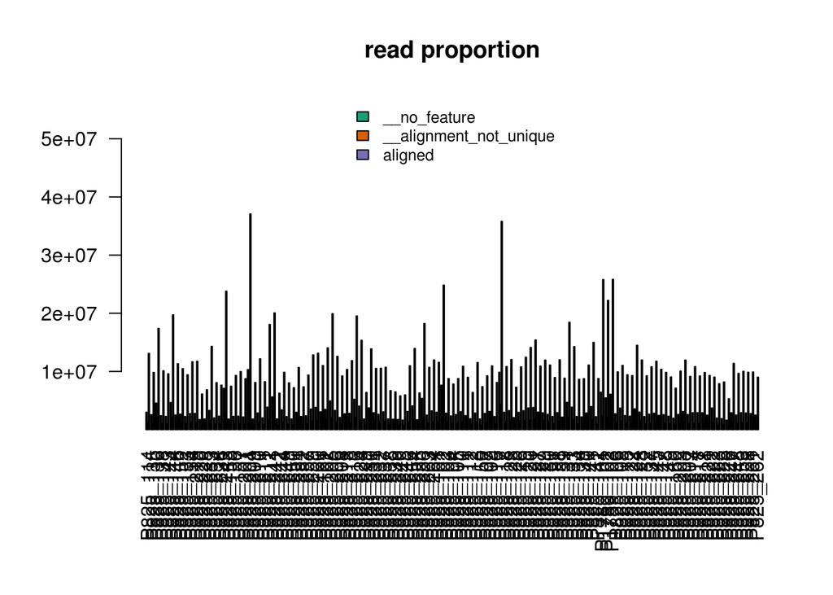

```r
pal=brewer.pal(6,"Dark2")[1:nrow(count.stats)]
par(mar=c(7.1,5.1,4.1,2.1))
barplot(as.matrix(count.stats),col=pal,beside=TRUE,las=2,main="read proportion",
        ylim=range(count.stats) + c(0,2e+7))
legend("top",fill=pal,legend=rownames(count.stats),bty="n",cex=0.8)
```

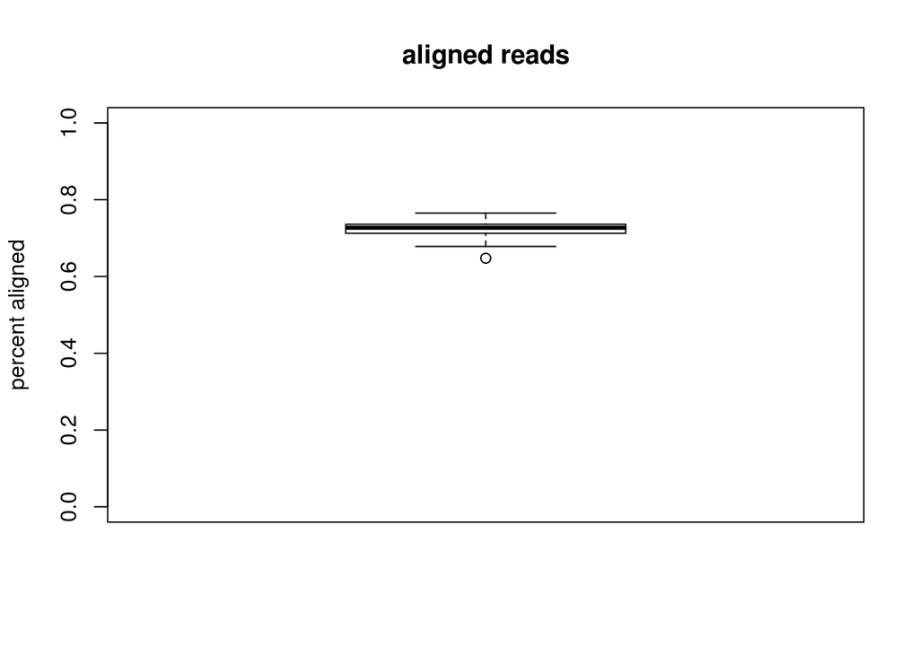

```r
par(mar=mar)

boxplot(unlist(count.stats["aligned",]/colSums(count.stats)),main="aligned reads",ylab="percent aligned",ylim=c(0,1))
```

25.7% of the genes are not expressed out of a total of 70736 genes

```r
sel <- rowSums(count.table) == 0
sprintf("%s percent",round(sum(sel) * 100/ nrow(count.table),digits=1))
```

```
## [1] "25.7 percent"
```

```r
sprintf("of %s genes are not expressed",nrow(count.table))
```

```
## [1] "of 70736 genes are not expressed"
```

Display the per-gene mean expression; i.e. the mean raw count of every gene across samples is calculated and displayed on a log10 scale

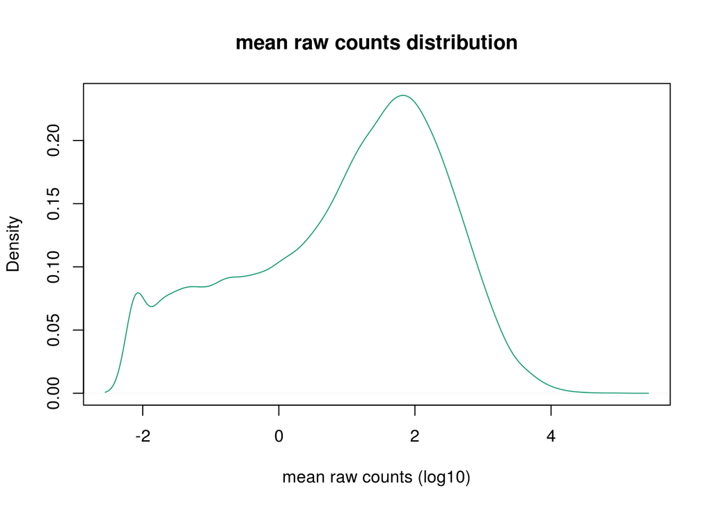

```r
plot(density(log10(rowMeans(count.table))),col=pal[1],
     main="mean raw counts distribution",
     xlab="mean raw counts (log10)")
```

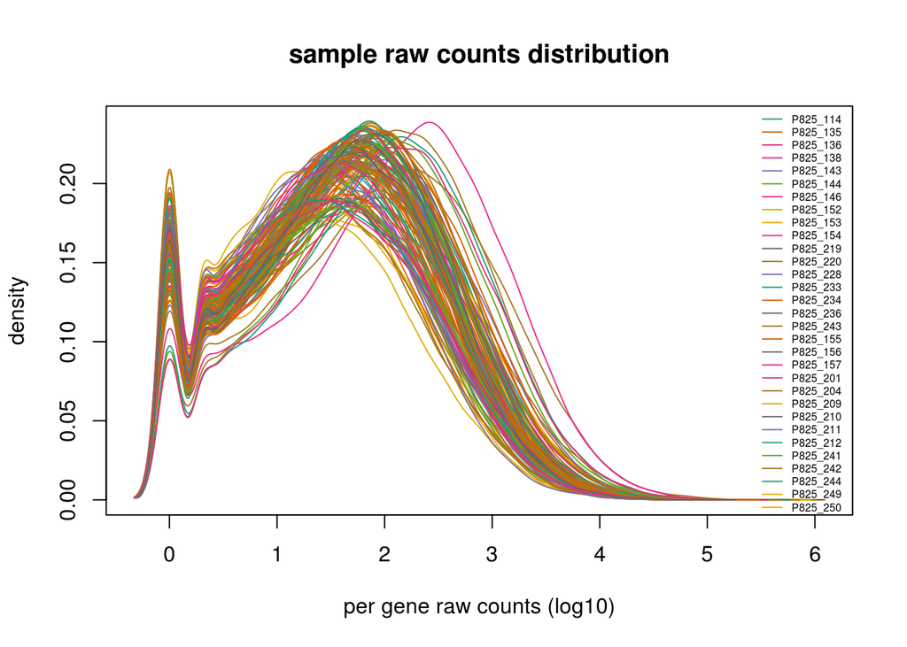

```r
pal=brewer.pal(8,"Dark2")
plot.multidensity(log10(count.table),col=sample(pal,length(res),TRUE),
                  legend.x="topright",legend.cex=0.5,
                  main="sample raw counts distribution",
                  xlab="per gene raw counts (log10)")
```

For visualization, the data is submitted to a variance stabilization transformation using DESeq2. The dispersion is estimated independently of the sample type.

```r
conditions <- colnames(count.table)
dds <- DESeqDataSetFromMatrix(
  countData = count.table,
  colData = data.frame(condition=conditions,
                       date=samples$Date,
                       tissue=samples$Tissue),
  design = ~ condition)
```

## 2.1 VST blind = TRUE

```r
colData(dds)$condition <- factor(colData(dds)$condition,
                                 levels=unique(conditions))
vsd <- varianceStabilizingTransformation(dds, blind=TRUE)
vst <- assay(vsd)
vst <- vst - min(vst)
```

Visualize the corrected mean - sd relationship. It is not exactly linear, but we can still assume homoscedasticity for the purpose of QA.

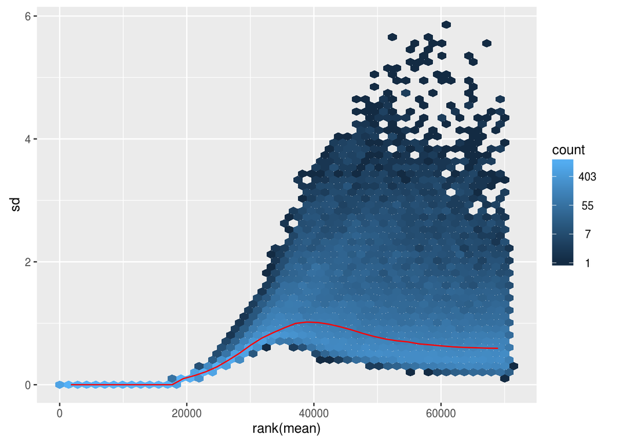

```r
meanSdPlot(vst)
```

### 2.1.1 PCA

Perform a Principal Component Analysis (PCA) of the data to do a quick quality assessment; i.e. replicate should cluster and the first dimensions should be explainable by biological means.

```r
pc <- prcomp(t(vst))
percent <- round(summary(pc)$importance[2,]*100)
```

Plot the PCA 3 first dimensions

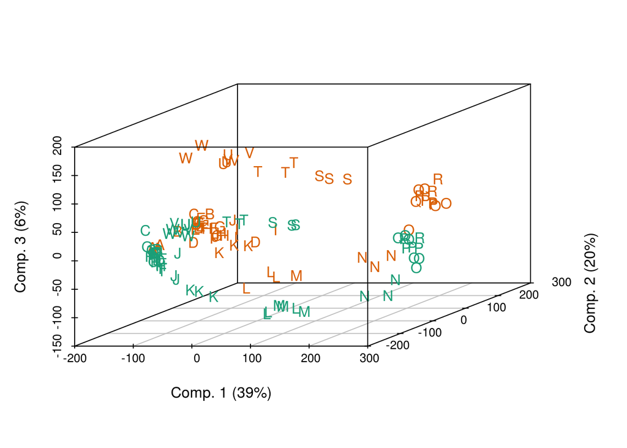

```r
replicates <- factor(samples$Sampling)
colours <- ifelse(samples$Tissue=="Phloem",
                  cols[1],cols[2])

scatterplot3d(pc$x[,1],
              pc$x[,2],
              pc$x[,3],
              xlab=paste("Comp. 1 (",percent[1],"%)",sep=""),
              ylab=paste("Comp. 2 (",percent[2],"%)",sep=""),
              zlab=paste("Comp. 3 (",percent[3],"%)",sep=""),
              color=colours,
              pch=LETTERS[replicates])
```

## 2.2 VST blind = FALSE

We now redo the vst in a model aware fashion. The model is based on the previous knowledge as can be observed above that tissue and date are essential factors (20% and 45% (PC1 and PC3 cumulated), respectively)

```r
design(dds) <- ~tissue + date
vsd <- varianceStabilizingTransformation(dds, blind=FALSE)
bst <- assay(vsd)
bst <- bst - min(bst)
```

The plot shows an almost ideal mean-sd relationship, the data looks almost perfectly homoscedastic.

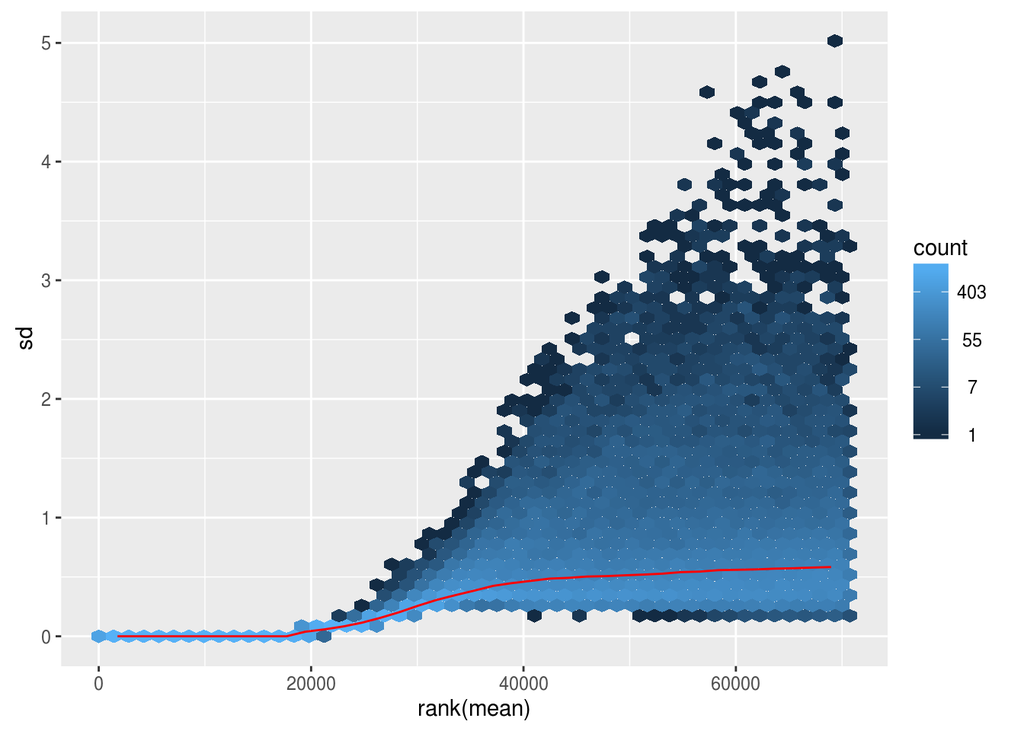

```r
meanSdPlot(bst)
```

### 2.2.1 PCA

The PCA looks very similar to the ‘blind’ one, but the first 3D explains 6% more of the overall variability!

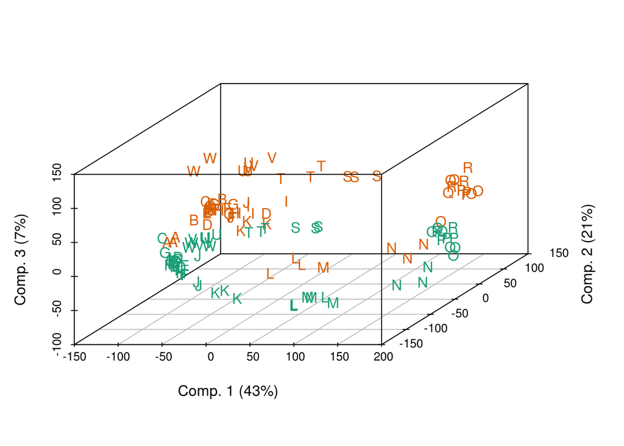

```r
pc <- prcomp(t(bst))
percent <- round(summary(pc)$importance[2,]*100)
scatterplot3d(pc$x[,1],
              pc$x[,2],
              pc$x[,3],
              xlab=paste("Comp. 1 (",percent[1],"%)",sep=""),
              ylab=paste("Comp. 2 (",percent[2],"%)",sep=""),
              zlab=paste("Comp. 3 (",percent[3],"%)",sep=""),
              color=colours,
              pch=LETTERS[replicates])
```

```r
par(mar=mar)
```

## 2.3 Comparison

### 2.3.1 Basic

The matrices distribution show differences

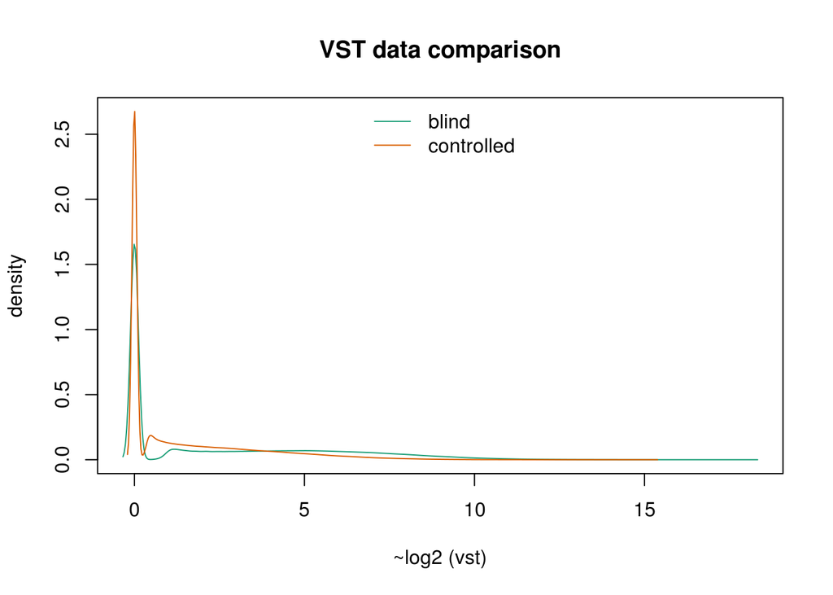

```r
plot.multidensity(list(blind=vst,controlled=bst),
                  xlab="~log2 (vst)",main="VST data comparison")
```

```r
stopifnot(identical(dimnames(bst),dimnames(vst)))
```

Which appear to be frequent and highly variable

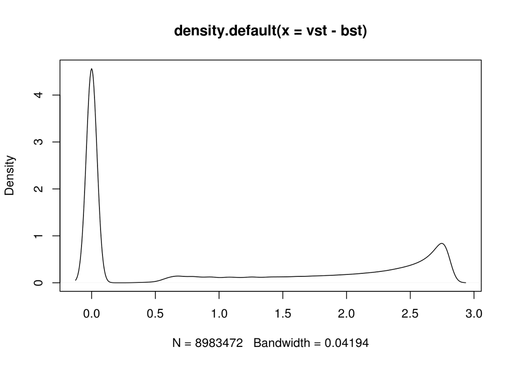

```r
plot(density(vst - bst))
```

In a consistent manner

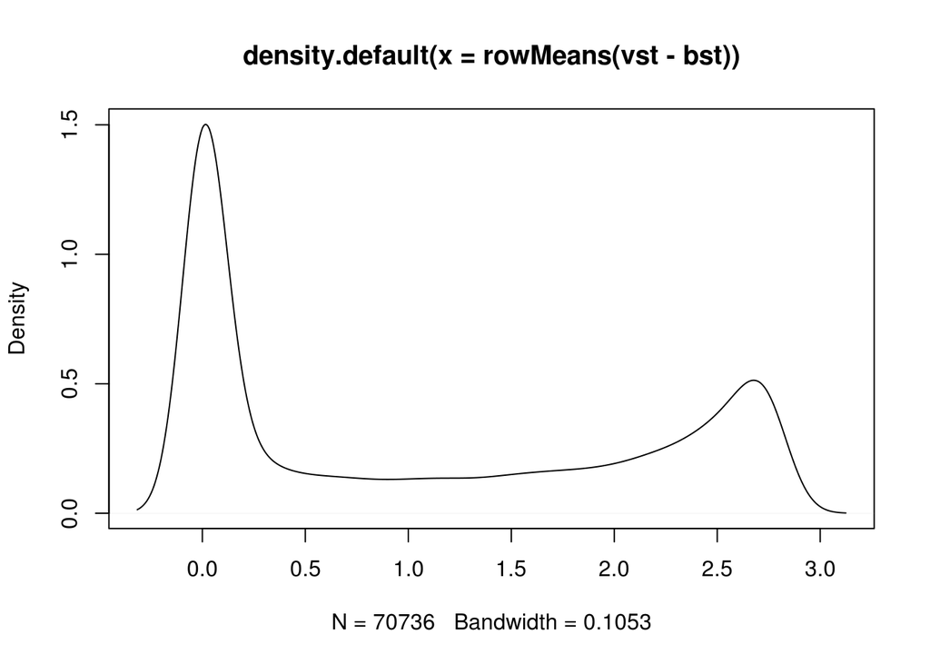

```r
plot(density(rowMeans(vst - bst)))
```

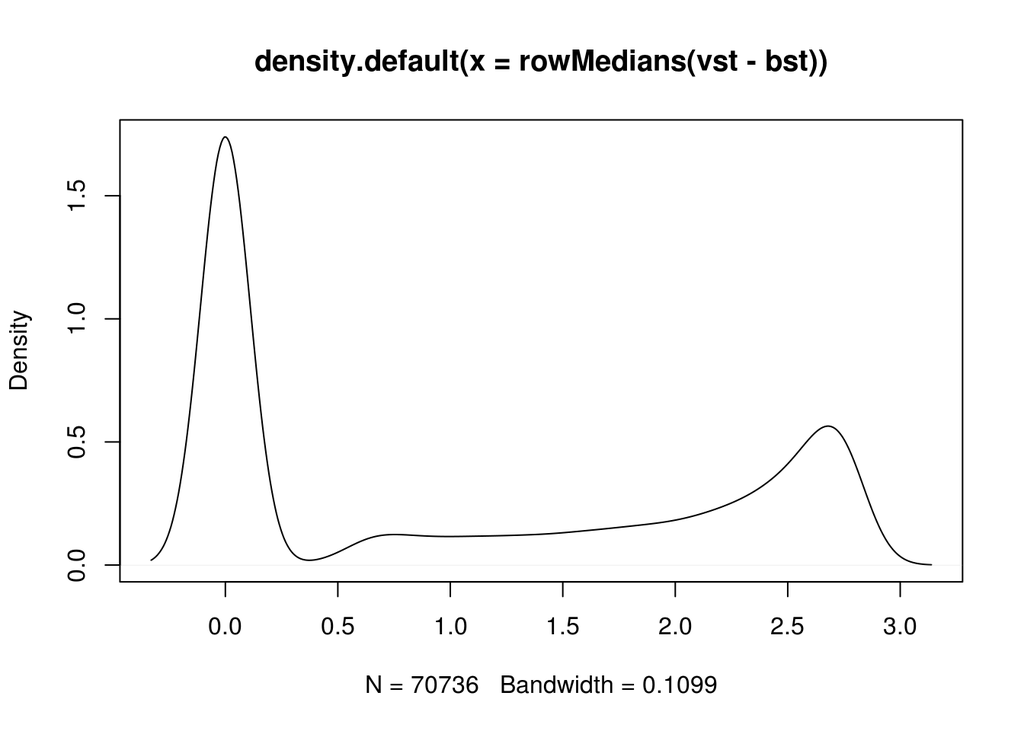

```r
plot(density(rowMedians(vst - bst)))
```

```r
sum(rowMedians(vst - bst) != 0)
```

```
## [1] 36793
```

### 2.3.2 Heatmap

Looking at the 1000 most affected genes

```r
sel <- order(rowMedians(vst - bst),decreasing=TRUE)[1:1000]
```

VST aware

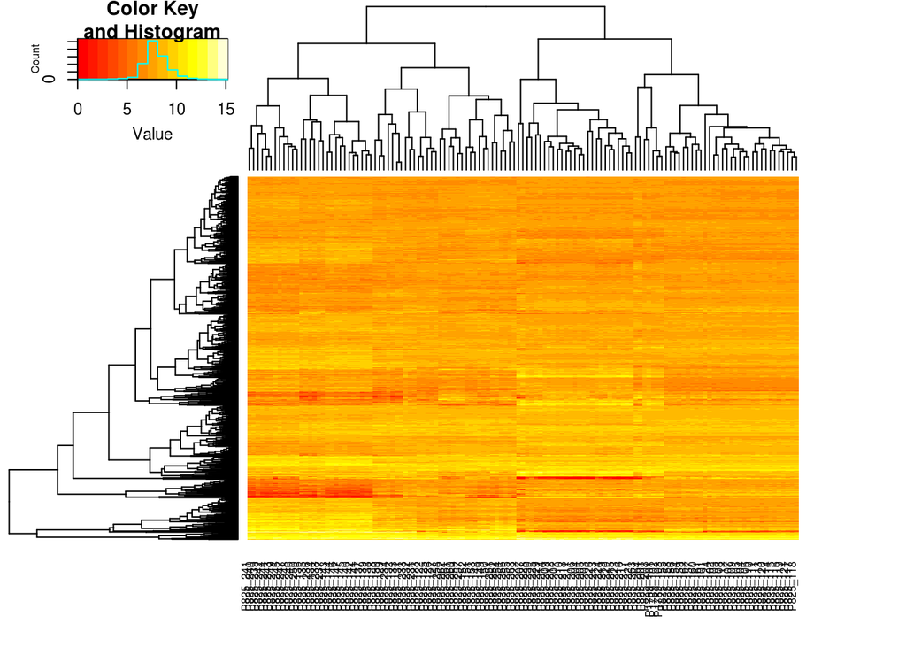

```r
heatmap.2(bst[sel,],labRow = NA,trace = "none",cexCol = 0.6 )
```

VST blind

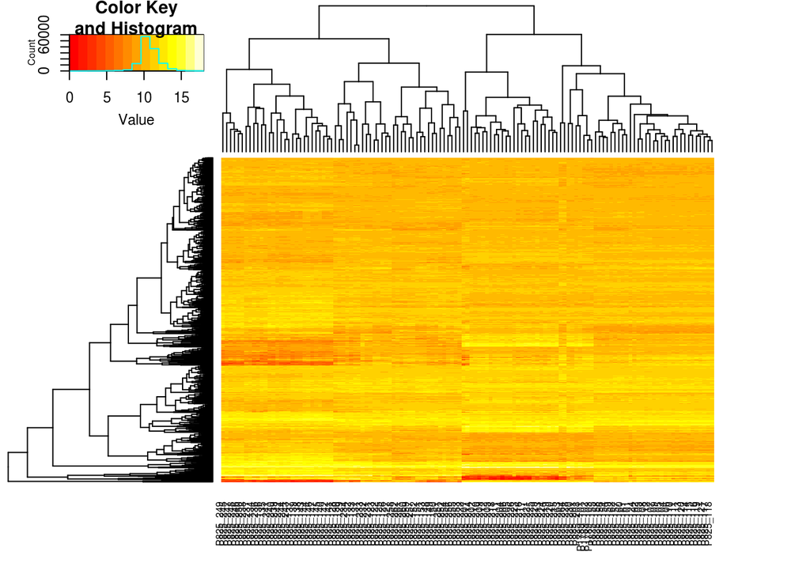

```r
heatmap.2(vst[sel,],labRow = NA,trace = "none",cexCol = 0.6 )
```

Aware with some extra info; the sampling times across the season (x axis labels) and the tissues (color code at the top, green == Phloem)

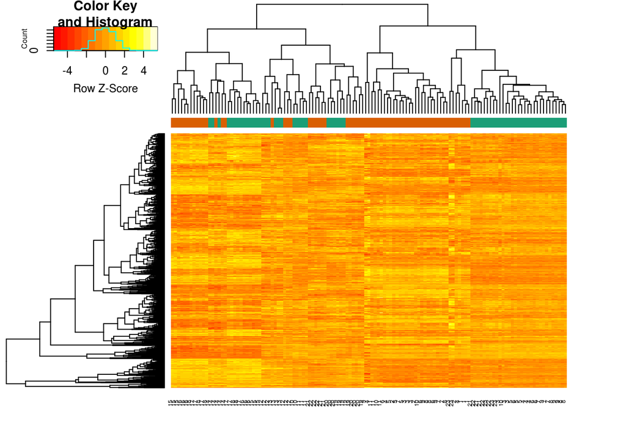

```r
heatmap.2(bst[sel,],labRow = NA,trace = "none",cexCol = 0.6, scale="row",
          labCol=replicates,ColSideColors=colours)
```

Save the object for further assessment

```r
save(dds,vst,bst,file="analysis/vst_blind-and-aware_results.rda")
```